# Visualização com ggplot2

# Introdução

Para fazer esta lista, crie um notebook no Rstudio. Tente separar os exercícios em *chunks* e documentar os comentários/respostas pertinentes. Os exercícios foram retirados do livro [R for Data Scientists](https://r4ds.had.co.nz/), e este pode e deve ser consultado para auxiliar nas resoluções.

Para os próximos exercícios, iremos utilizar um dataset do pacote `ggplot2` chamado `mpg`. Primeiramente, você deverá carregar o `tidyverse` (lembre-se que o `tidyverse` é uma coletânea de pacotes, e um deles é o `ggplot2`):

```
library(tidyverse)
```

Podemos acessar o help do Rstudio para sabermos mais sobre este dataset. Fazemos isso com o comando `?mpg` ou `help(mpg)`. Para facilitar a manipulação e visualização, iremos criar uma variável chamada `df` (abreviação de data frame) para armazenar `mpg`.

```r
df<-mpg
```

Note que a variável `df` aparece na lista de variáveis no Global Environment. Podemos usar o visualizador do Rstudio para ver `df` como se fosse uma “tabela de Excel” - clique na variável `df` no Global Environmet, ou digite o código `view(df)`. Note também que, como `mpg` vem do tidyverse, df já é um `tibble`, nossa estrutura de dados de preferência. Para checar isso, podemos usar a função `is_tibble()`:

```r
df %>% is_tibble()
## [1] TRUE

# equivalente a: is_tibble(df)
```

O pacote `ggplot2` fornece ferramentas muito poderosas para visualização de dados. Aqui iremos introduzir apenas a sintaxe mais básica para gerar um gráfico; vamos fazer um *scatterplot* (gráfico de dispersão). Para isso, precisamos fornecer à função `ggplot()` um dataframe, quais colunas queremos utilizar e o tipo de visualização. Isto é feito da seguinte forma:

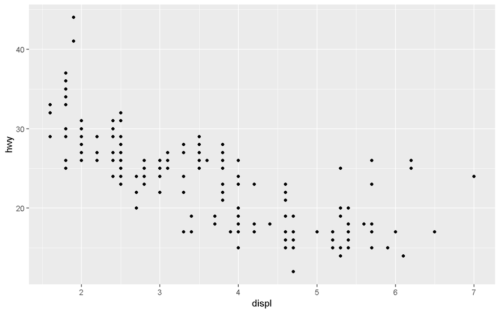

```r
df %>% ggplot(aes(x = displ, y = hwy)) +
  geom_point()
```

O ggplot oferece grande versatilidade para exibirmos nossos dados, para maiores informações sobre como fazer os variados tipos de gráficos, acesse [r4ds](https://r4ds.had.co.nz/data-visualisation.html) e [R Graph Gallery](https://www.r-graph-gallery.com/) . Além disso, este [cheatsheet](https://www.rstudio.com/wp-content/uploads/2015/03/ggplot2-cheatsheet.pdf) pode ser útil.

# Exercícios

1. Quantas linhas `df` possui? E colunas? (Faça usando código R)
2. O que a variável `drv` descreve? (Leia o help em `?mpg`)
3. Faça um *scatterplot* de`hwy`por `cyl`. Que relação podemos traçar entre estas variáveis? Como podemos explicar essa relação?
4. O que acontece se você fizer um *scatterplot* entre `class` e `drv`? Porque este gráfico não é útil? Você consegue pensar em uma visualização que seria mais útil para essas variáveis?
5. Quais variáveis de `df` são categóricas? Quais são contínuas? (lembre-se de ler a documentação em `?mpg`). Como poderíamos descobrir isso a partir de `df`?
6. Lembre-se que podemos criar um *grid* de gráficos no ggplot adicionando `facet_wrap()`.
   - Rode:

     ```
     df %>% ggplot(aes(x = displ, y = hwy)) +
       geom_point() +
       facet_wrap(~ class, nrow = 2)
     ```

   - Agora rode o seguinte código. O que ele faz?

     ```
     df %>% ggplot(aes(x = displ, y = hwy)) +
       geom_point() +
       facet_wrap(vars(cyl,drv), nrow = 3)
     ```

7. Adicione um faceteamento no gráfico da questão 4 utilizando a variável `manufacturer`. Escolha o número adequado de linhas (`nrow`) para a visualização. Este faceteamento foi útil? Por quê?